# Introduction to SC19019

## Question2

Slides page31.Power compasion(distance correlation test versus ball covariance test)

Model 1:$Y=X/4+e$

Model 2:$Y=X/4*e$

$X\sim N(0_2,I_2),e\sim N(0_2,I_2)$,$X$ and $e$ are independent.

## Answer2

Use the ways in the slides.

```r
library(MASS)
library(Ball)
library(boot)
```

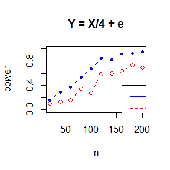

```r
dCov <- function(x, y) {
x <- as.matrix(x); y <- as.matrix(y)
n <- nrow(x); m <- nrow(y)
if (n != m || n < 2) stop("Sample sizes must agree")
if (! (all(is.finite(c(x, y)))))
stop("Data contains missing or infinite values")
Akl <- function(x) {
d <- as.matrix(dist(x))
m <- rowMeans(d); M <- mean(d)
a <- sweep(d, 1, m); b <- sweep(a, 2, m)
b + M
}
A <- Akl(x); B <- Akl(y)
sqrt(mean(A * B))
}
ndCov2 <- function(z, ix, dims) {
#dims contains dimensions of x and y
p <- dims[1]
q <- dims[2]
d <- p + q
x <- z[ , 1:p] #leave x as is
y <- z[ix, -(1:p)] #permute rows of y
return(nrow(z) * dCov(x, y)^2)
}
n = seq(20,200,20)
m = 100

p.cor = matrix(0,length(n),2)
p.ball = matrix(0,length(n),2)

for (i in 1:length(n)){

  p.cor_sim = matrix(0, m, 2)
  p.ball_sim = matrix(0, m, 2)

  for (j in 1:m){
    set.seed(12345+j)
    x = mvrnorm(n[i],mu=rep(0,2),Sigma=diag(rep(1,2)))
    e = mvrnorm(n[i],mu=rep(0,2),Sigma=diag(rep(1,2)))
    y1 = x/4 + e
    y2 = x/4*e
    #model1
    boot.obj1 = boot(data = cbind(x,y1), statistic = ndCov2, R = 99, sim = "permutation", dims = c(2, 2))
    #permutatin: resampling without replacement
    tb1 = c(boot.obj1$t0, boot.obj1$t)
    p.cor_sim[j,1] = mean(tb1>=tb1[1])
    p.ball_sim[j,1] = bcov.test(x,y1,num.permutations=99,seed=j)$p.value
    #model2
    boot.obj2 = boot(data = cbind(x,y2), statistic = ndCov2, R = 99, sim = "permutation", dims = c(2, 2))
    #permutatin: resampling without replacement
    tb2 = c(boot.obj2$t0, boot.obj2$t)
    p.cor_sim[j,2] = mean(tb2>=tb2[1])
    p.ball_sim[j,2] = bcov.test(x,y2,num.permutations =99,seed=j)$p.value
  }
  p.cor[i,] = colMeans(p.cor_sim < 0.05)
  p.ball[i,] = colMeans(p.ball_sim < 0.05 )
}

# plot
plot(x=n, y=p.cor[,1], type="b", pch=20, main="Y = X/4 + e", ylab='power', col='blue', ylim = c(0,1))
legend(x=160, y=0.4, legend = c("distance","ball"), lty=1:2, col = c('blue','red'))
lines(x = n, y=p.ball[,1], type="b", lty=2, col='red')
```

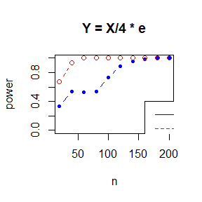

```r
plot(x=n, y=p.cor[,2], type="b", pch=20, main="Y = X/4 * e", ylab='power', col='blue', ylim = c(0,1))
legend(x=160,y=0.4,legend = c("distance","ball"),lty=1:2, col = c('blue','red'))
lines(x = n, y=p.ball[,2], type="b", lty=2, col='red')
```

## Question

Implement a random walk Metropolis sampler for generating the standard Laplace distribution (see Exercise 3.2). For the increment, simulate from a normal distribution. Compare the chains generated when different variances are used for the proposal distribution. Also, compute the acceptance rates of each chain.

## Answer

The density function of Laplace is $f(x)=0.5e^{-|x|},x\in R$.

```r
f=function(x) 0.5*exp(-abs(x))
```

In this simulation below, the Laplace densities in r(xi−1, y) will be computed by the f function write by myself.Then y is accepted or rejected and Xi generated by

if (u[i] <= f(y, n) / f(x[i-1], n)) x[i] <- y else x[i] <- x[i-1]

These steps are combined into a function to generate the chain, given the parameters n and σ, initial value X0, and the length of the chain, N.

```r
rw.Metropolis <- function(sigma, x0, N) {
x <- numeric(N)
x[1] <- x0
u <- runif(N)
k <- 0
for (i in 2:N) {
y <- rnorm(1, x[i-1], sigma)
if (u[i] <= (f(y) / f(x[i-1]))) x[i] <- y
else {
x[i] <- x[i-1]
k <- k + 1
}
}
return(list(x=x, k=k))
}
```

Four chains are generated for different variances σ2 of the proposal distribution.

```r
N <- 2000
sigma <- c(.05, .5, 2, 16)
x0 <- 25
rw1 <- rw.Metropolis( sigma[1], x0, N)
rw2 <- rw.Metropolis( sigma[2], x0, N)
rw3 <- rw.Metropolis( sigma[3], x0, N)
rw4 <- rw.Metropolis( sigma[4], x0, N)
#number of candidate points rejected
print(c(rw1$k, rw2$k, rw3$k, rw4$k))
```

```
## [1]   47  328  924 1804
```

Show the plots.

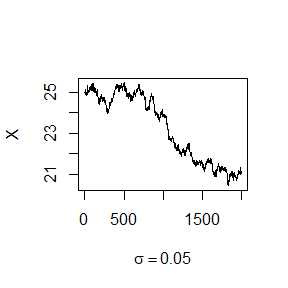

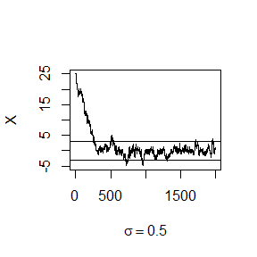

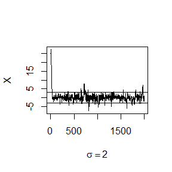

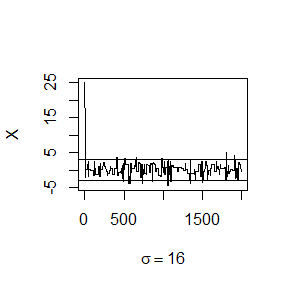

```r
library(GeneralizedHyperbolic)
refline <- qskewlap(c(.025, .975),param=c(0,1,1))
rw <- cbind(rw1$x, rw2$x, rw3$x, rw4$x)
for (j in 1:4) {
plot(rw[,j], type="l",
xlab=bquote(sigma == .(round(sigma[j],3))),
ylab="X", ylim=range(rw[,j]))
abline(h=refline)
}
```

## Question1

The natural logarithm and exponential functions are inverses of each other, so that mathematically log(exp x) = exp(log x) = x. Show by example that this property does not hold exactly in computer arithmetic. Does the identity hold with near equality? (See all.equal.)

## Answer1

### computer arithmetic

```r
f1 = function(x) log(exp(x))
f2 = function(x) exp(log(x))
x=1:10
f1(x) == f2(x)
```

```
##  [1]  TRUE  TRUE FALSE  TRUE FALSE  TRUE FALSE FALSE FALSE FALSE
```

```r
f1(x) == x
```

```
##  [1] TRUE TRUE TRUE TRUE TRUE TRUE TRUE TRUE TRUE TRUE
```

```r
f2(x) == x
```

```
##  [1]  TRUE  TRUE FALSE  TRUE FALSE  TRUE FALSE FALSE FALSE FALSE
```

### Use “isTRUE” with near equality

```r
c(isTRUE(all.equal(f1(x),f2(x))),isTRUE(all.equal(f1(x),x)),isTRUE(all.equal(f2(x),x)))
```

```
## [1] TRUE TRUE TRUE
```

### conclusion

By example that this property does not hold exactly in computer arithmetic. The identity hold with near equality. (See all.equal.)

## Question2

Write a function to solve the equation
$$\frac{2 \Gamma\left(\frac{k}{2}\right)}{\sqrt{\pi(k-1)} \Gamma\left(\frac{k-1}{2}\right)} \int_{0}^{c_{k-1}}\left(1+\frac{u^{2}}{k-1}\right)^{-k / 2} d u\\=\frac{2 \Gamma\left(\frac{k+1}{2}\right)}{\sqrt{\pi k} \Gamma\left(\frac{k}{2}\right)} \int_{0}^{c_{k}}\left(1+\frac{u^{2}}{k}\right)^{-(k+1) / 2} d u$$

for a, where
$$c_{k}=\sqrt{\frac{a^{2} k}{k+1-a^{2}}}$$

Compare the solutions with the points A(k) in Exercise 11.4.

## Answer2

Write a function f to express RHS in exercise11.5.

```r
f = function(a,k){
  c_k = sqrt(a^2*k/(k+1-a^2))
  c1 = 2*gamma((k+1)/2)
  c2 = sqrt(pi*k)*gamma(k/2)
  f_in = function(x) (1+x^2/k)^(-(k+1)/2)
  c3 = integrate(f=f_in,lower=0,upper=c_k)$value
  return(c1/c2*c3)
}
```

```r
k = c(4:25,100);n=length(k);
solution = numeric(n)
for(i in 1:n){
solution[i] = uniroot(function(a){f(a,k=k[i]-1)-f(a,k=k[i])},interval=c(-2,1))$root
}
library(knitr)
kable(cbind(k,solution),format="markdown")
```

| k | solution |
| --- | --- |
| 4 | -1.492104 |
| 5 | -1.533559 |
| 6 | -1.562732 |
| 7 | -1.584422 |
| 8 | -1.601184 |
| 9 | -1.614522 |
| 10 | -1.625392 |
| 11 | -1.634420 |
| 12 | -1.642039 |
| 13 | -1.648554 |
| 14 | -1.654189 |
| 15 | -1.659112 |
| 16 | -1.663449 |
| 17 | -1.667298 |
| 18 | -1.670739 |
| 19 | -1.673832 |
| 20 | -1.676628 |
| 21 | -1.679168 |
| 22 | -1.681485 |
| 23 | -1.683608 |
| 24 | -1.685559 |
| 25 | -1.687359 |
| 100 | -1.720606 |

Write a function s to express the equation in exercise11.4.
$$S_{k}(a)=P(t(k)>\sqrt{\frac{a^{2} k}{k+1-a^{2}}})$$

```r
s = function(a,k){
  q = sqrt(a^2*k/(k+1-a^2))
  s = pt(q,k)
  return(s)
}
```

Find the intersection points in exercise11.4.

```r
A_k = numeric(n)
for(i in 1:n){
  g2 = function(a) s(a,k[i]-1)-s(a,k[i])
  A_k[i] = uniroot(g2,interval=c(-2,1))$root
}
kable(cbind(k,A_k),format="markdown")
```

| k | A_k |
| --- | --- |
| 4 | -1.492104 |
| 5 | -1.533559 |
| 6 | -1.562732 |
| 7 | -1.584422 |
| 8 | -1.601184 |
| 9 | -1.614522 |
| 10 | -1.625392 |
| 11 | -1.634420 |
| 12 | -1.642039 |
| 13 | -1.648554 |
| 14 | -1.654189 |
| 15 | -1.659112 |
| 16 | -1.663449 |
| 17 | -1.667298 |
| 18 | -1.670739 |
| 19 | -1.673832 |
| 20 | -1.676628 |
| 21 | -1.679168 |
| 22 | -1.681485 |
| 23 | -1.683608 |
| 24 | -1.685559 |
| 25 | -1.687359 |
| 100 | -1.720606 |

### compare

```r
kable(cbind(k,solution,A_k),format="markdown")
```

| k | solution | A_k |
| --- | --- | --- |
| 4 | -1.492104 | -1.492104 |
| 5 | -1.533559 | -1.533559 |
| 6 | -1.562732 | -1.562732 |
| 7 | -1.584422 | -1.584422 |
| 8 | -1.601184 | -1.601184 |
| 9 | -1.614522 | -1.614522 |
| 10 | -1.625392 | -1.625392 |
| 11 | -1.634420 | -1.634420 |
| 12 | -1.642039 | -1.642039 |
| 13 | -1.648554 | -1.648554 |
| 14 | -1.654189 | -1.654189 |
| 15 | -1.659112 | -1.659112 |
| 16 | -1.663449 | -1.663449 |
| 17 | -1.667298 | -1.667298 |
| 18 | -1.670739 | -1.670739 |
| 19 | -1.673832 | -1.673832 |
| 20 | -1.676628 | -1.676628 |
| 21 | -1.679168 | -1.679168 |
| 22 | -1.681485 | -1.681485 |
| 23 | -1.683608 | -1.683608 |
| 24 | -1.685559 | -1.685559 |
| 25 | -1.687359 | -1.687359 |
| 100 | -1.720606 | -1.720606 |

### conclusion

The solution in exercise11.5 are same to A(k) in exercise11.4.

## Question3

A-B-O blood type problem. Let the three alleles be A, B, and O with allele frequencies p, q, and r. The 6 genotype frequencies under HWE and complete counts see in homework pdf.

Observed data: nA· = nAA + nAO = 28 (A-type),nB· = nBB + nBO = 24 (B-type), nOO = 41 (O-type),nAB = 70 (AB-type).

1.Use EM algorithm to solve MLE of p and q (consider missing data nAA and nBB).

2.Show that the log-maximum likelihood values in M-steps are increasing via line plot.

## Answer3

The complete data likelihood is:
$$L(p,q|n_{AA},n_{BB},n_{OO},n_{AO},n_{BO},n_{AB})=(p^2)^{n_{AA}}(q^2)^{n_{BB}}(r^2)^{n_{OO}}(2pr)^{n_{AO}}(2qr)^{n_{BO}}(2pq)^{n_{AB}}$$

The log-likelihood is:
$$l(p,q|n_{AA},n_{BB},n_{OO},n_{AO},n_{BO},n_{AB})=2n_{AA}log(p)+2n_{BB}log(q)+2n_{OO}log(r)+n_{AO}log(2pr)+n_{BO}log(2qr)+n_{AB}log(2pq)$$

The expert of the log-likelihood is:
$$E_{p_0,q_0}[l(p,q|n_{AA},n_{BB},n_{OO},n_{AO},n_{BO},n_{AB})]=\frac{2p_0}{p_0+2(1-p_0-q_0)}n_{A.}log(p)+\frac{2q_0}{q_0+2(1-p_0-q_0)}n_{B.}log(q)+2n_{OO}log(1-p-q)+\frac{2(1-p_0-q_0)}{p_0+2(1-p_0-q_0)}n_{A.}log(2p(1-p-q))+\frac{2(1-p_0-q_0)}{q_0+2(1-p_0-q_0)}n_{B.}log(2q(1-p-q))+n_{AB}log(2pq)$$

Now,begin the EM algorithm to solve the mle of p and q:

```r
nA=28;nB=24;nOO=41;nAB=70;
E_log=function(x0,x){p=x[1];q=x[2];p0=x0[1];q0=x0[2];
s=(2*p0/(p0+2*(1-p0-q0))*nA*log(p)+2*q0/(q0+2*(1-p0-q0))*nB*log(q)+2*nOO*log(1-p-q)+2*(1-p0-q0)/(p0+2*(1-p0-q0))*nA*log(2*p*(1-p-q))+2*(1-p0-q0)/(q0+2*(1-p0-q0))*nB*log(2*q*(1-p-q))+nAB*log(2*p*q))
return(-s)}
optim(c(0.3,0.4),E_log,x0=c(0.2,0.3))
```

```
## $par
## [1] 0.3149542 0.3053138
##
## $value
## [1] 279.0866
##
## $counts
## function gradient
##       51       NA
##
## $convergence
## [1] 0
##
## $message
## NULL
```

### conclusion1

So the Mle of p is 0.3149542, the Mle of q is 0.3053138.

Show the log-maximum likelihood values in M-steps via line plot:

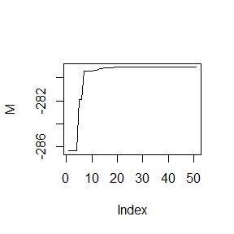

```r
M=numeric(51)
for(i in 1:51){
  M[i]=-optim(c(0.3,0.4),E_log,x0=c(0.2,0.3),control=list(maxit=i))$value
}
plot(M,type="l")
```

### conclusion2

The line plot shows that the log-maximum likelihood values in M-steps are increasing.

## Question1

Use both for loops and lapply() to fit linear models to the mtcars using the formulas stored in this list: formulas <- list( mpg ~ disp, mpg ~ I(1 / disp), mpg ~ disp + wt, mpg ~ I(1 / disp) + wt )

## Answer1

```r
x=mtcars;mpg=x$mpg;disp=x$disp;wt=x$wt
formulas <- list(
mpg ~ disp,
mpg ~ I(1 / disp),
mpg ~ disp + wt,
mpg ~ I(1 / disp) + wt
)
```

Use lapply() to fit linear models:

```r
out1=lapply(formulas,lm)
out1
```

```
## [[1]]
##
## Call:
## FUN(formula = X[[i]])
##
## Coefficients:
## (Intercept)         disp
##    29.59985     -0.04122
##
##
## [[2]]
##
## Call:
## FUN(formula = X[[i]])
##
## Coefficients:
## (Intercept)    I(1/disp)
##       10.75      1557.67
##
##
## [[3]]
##
## Call:
## FUN(formula = X[[i]])
##
## Coefficients:
## (Intercept)         disp           wt
##    34.96055     -0.01772     -3.35083
##
##
## [[4]]
##
## Call:
## FUN(formula = X[[i]])
##
## Coefficients:
## (Intercept)    I(1/disp)           wt
##      19.024     1142.560       -1.798
```

Use for loops to fit linear models:

```r
out2=vector("list",length(formulas))
for(i in seq_along(formulas)){
  out2[[i]]=lm(formulas[[i]])
}
out2
```

```
## [[1]]
##
## Call:
## lm(formula = formulas[[i]])
##
## Coefficients:
## (Intercept)         disp
##    29.59985     -0.04122
##
##
## [[2]]
##
## Call:
## lm(formula = formulas[[i]])
##
## Coefficients:
## (Intercept)    I(1/disp)
##       10.75      1557.67
##
##
## [[3]]
##
## Call:
## lm(formula = formulas[[i]])
##
## Coefficients:
## (Intercept)         disp           wt
##    34.96055     -0.01772     -3.35083
##
##
## [[4]]
##
## Call:
## lm(formula = formulas[[i]])
##
## Coefficients:
## (Intercept)    I(1/disp)           wt
##      19.024     1142.560       -1.798
```

### conclusion

As we can see, the results are equal.

## Question2

Fit the model mpg ~ disp to each of the bootstrap replicates of mtcars in the list below by using a for loop and lapply(). Can you do it without an anonymous function? bootstraps <- lapply(1:10, function(i) { rows <- sample(1:nrow(mtcars), rep = TRUE) mtcars[rows, ] })

## Answer2

```r
bootstraps <- lapply(1:10, function(i) {
rows <- sample(1:nrow(mtcars), rep = TRUE)
mtcars[rows, ]
})
out22=vector("list",length(bootstraps))
for(i in seq_along(bootstraps)){
mpg=bootstraps[[i]]$mpg;disp=bootstraps[[i]]$disp
formula2 <- list(mpg ~ disp)
out22[i]=lapply(formula2,lm)
}
out22
```

```
## [[1]]
##
## Call:
## FUN(formula = X[[i]])
##
## Coefficients:
## (Intercept)         disp
##    29.76139     -0.04182
##
##
## [[2]]
##
## Call:
## FUN(formula = X[[i]])
##
## Coefficients:
## (Intercept)         disp
##    28.48808     -0.03787
##
##
## [[3]]
##
## Call:
## FUN(formula = X[[i]])
##
## Coefficients:
## (Intercept)         disp
##    24.66158     -0.02386
##
##
## [[4]]
##
## Call:
## FUN(formula = X[[i]])
##
## Coefficients:
## (Intercept)         disp
##    30.46222     -0.04588
##
##
```

[output cut: 43 more lines]

```
## FUN(formula = X[[i]])
##
## Coefficients:
## (Intercept)         disp
##    31.43671     -0.04505
##
##
## [[10]]
##
## Call:
## FUN(formula = X[[i]])
##
## Coefficients:
## (Intercept)         disp
##    26.76965     -0.03105
```

## Question3

For each model in the previous two exercises, extract R2 using the function below. rsq <- function(mod) summary(mod)$r.squared

## Answer3

```r
rsq <- function(mod) summary(mod)$r.squared
lapply(out1,rsq)
```

```
## [[1]]
## [1] 0.7183433
##
## [[2]]
## [1] 0.8596865
##
## [[3]]
## [1] 0.7809306
##
## [[4]]
## [1] 0.8838038
```

```r
lapply(out22,rsq)
```

```
## [[1]]
## [1] 0.7074488
##
## [[2]]
## [1] 0.7133107
##
## [[3]]
## [1] 0.5979348
##
## [[4]]
## [1] 0.7066548
##
## [[5]]
## [1] 0.7710829
##
## [[6]]
## [1] 0.72943
##
## [[7]]
## [1] 0.800463
##
## [[8]]
## [1] 0.7890272
##
## [[9]]
## [1] 0.6940357
##
## [[10]]
## [1] 0.7262248
```

## Question4

The following code simulates the performance of a t-test for non-normal data. Use sapply() and an anonymous function to extract the p-value from every trial. trials <- replicate( 100, t.test(rpois(10, 10), rpois(7, 10)), simplify = FALSE ) Extra challenge: get rid of the anonymous function by using [[ directly.

## Answer4

```r
set.seed(12144)
trials <- replicate(
100,
t.test(rpois(10, 10), rpois(7, 10)),
simplify = FALSE
)
p <- function(x) x$p.value
out41=sapply(trials,p)
```

Extra challenge:get rid of the anonymous function by using [[ directly.

```r
out42=numeric(length(trials))
for(i in seq_along(trials)){
  out42[[i]]=trials[[i]]$p.value
}
```

Show all the results:

```r
library(knitr)
kable(cbind(out41[1:25],out42[1:25],out41[26:50],out42[26:50],out41[51:75],out42[51:75],out41[76:100],out42[76:100]),col.names=c("out41_1to25","out42_1to25","out41_25to50","out42_25to50","out41_51to75","out42_51to75","out41_76to100","out42_76to100"))
```

| out41_1to25 | out42_1to25 | out41_25to50 | out42_25to50 | out41_51to75 | out42_51to75 | out41_76to100 | out42_76to100 |
| --- | --- | --- | --- | --- | --- | --- | --- |
| 0.9761938 | 0.9761938 | 0.7278662 | 0.7278662 | 0.2866347 | 0.2866347 | 0.5266921 | 0.5266921 |
| 0.5862387 | 0.5862387 | 0.6383333 | 0.6383333 | 0.2682156 | 0.2682156 | 0.8531925 | 0.8531925 |
| 0.2498112 | 0.2498112 | 0.4516551 | 0.4516551 | 0.9591801 | 0.9591801 | 0.0899471 | 0.0899471 |
| 0.9571877 | 0.9571877 | 0.0528421 | 0.0528421 | 0.8853547 | 0.8853547 | 0.9919305 | 0.9919305 |
| 0.2083097 | 0.2083097 | 0.5333465 | 0.5333465 | 0.1966333 | 0.1966333 | 0.2460569 | 0.2460569 |
| 0.7073715 | 0.7073715 | 0.0307247 | 0.0307247 | 0.7489229 | 0.7489229 | 0.2114538 | 0.2114538 |
| 0.5957758 | 0.5957758 | 0.7176983 | 0.7176983 | 0.9099036 | 0.9099036 | 0.8191146 | 0.8191146 |
| 0.1244764 | 0.1244764 | 0.5737246 | 0.5737246 | 0.6687695 | 0.6687695 | 0.1019239 | 0.1019239 |
| 0.9480669 | 0.9480669 | 0.1699227 | 0.1699227 | 0.3413291 | 0.3413291 | 0.9921176 | 0.9921176 |
| 0.0477723 | 0.0477723 | 0.7241925 | 0.7241925 | 0.0419733 | 0.0419733 | 0.7740922 | 0.7740922 |
| 0.7641073 | 0.7641073 | 0.0037328 | 0.0037328 | 0.5292005 | 0.5292005 | 0.9491512 | 0.9491512 |
| 0.3373463 | 0.3373463 | 0.2073225 | 0.2073225 | 0.2754364 | 0.2754364 | 0.3888104 | 0.3888104 |
| 0.5760590 | 0.5760590 | 0.7004099 | 0.7004099 | 0.0259960 | 0.0259960 | 0.1984086 | 0.1984086 |
| 0.0209231 | 0.0209231 | 0.7377785 | 0.7377785 | 0.1272594 | 0.1272594 | 0.5707502 | 0.5707502 |
| 0.9069196 | 0.9069196 | 0.1972085 | 0.1972085 | 1.0000000 | 1.0000000 | 0.8814378 | 0.8814378 |
| 0.5434601 | 0.5434601 | 0.1815241 | 0.1815241 | 0.8706611 | 0.8706611 | 0.0671156 | 0.0671156 |
| 0.0914023 | 0.0914023 | 0.5222295 | 0.5222295 | 0.0728935 | 0.0728935 | 0.6990846 | 0.6990846 |
| 0.8259166 | 0.8259166 | 0.2174376 | 0.2174376 | 0.4926285 | 0.4926285 | 0.7692092 | 0.7692092 |
| 0.1231629 | 0.1231629 | 0.7576790 | 0.7576790 | 0.3111611 | 0.3111611 | 0.4671096 | 0.4671096 |
| 0.6790078 | 0.6790078 | 0.6784561 | 0.6784561 | 0.1582279 | 0.1582279 | 0.3430368 | 0.3430368 |
| 0.4057455 | 0.4057455 | 0.9250207 | 0.9250207 | 0.6245988 | 0.6245988 | 0.9928924 | 0.9928924 |
| 0.4973659 | 0.4973659 | 0.6927621 | 0.6927621 | 0.9679310 | 0.9679310 | 0.3777695 | 0.3777695 |
| 0.0654128 | 0.0654128 | 0.0824274 | 0.0824274 | 0.9691214 | 0.9691214 | 0.7204927 | 0.7204927 |
| 0.2480894 | 0.2480894 | 0.0102717 | 0.0102717 | 0.4378873 | 0.4378873 | 0.7247050 | 0.7247050 |
| 0.5486241 | 0.5486241 | 0.4082568 | 0.4082568 | 0.1324739 | 0.1324739 | 0.0676868 | 0.0676868 |

The results of two methods are same.

## Question5

Implement mcsapply(), a multicore version of sapply(). Can you implement mcvapply(), a parallel version of vapply()? Why or why not?

## Answer5

For sapply:

```r
set.seed(121451)
fun <- function(x){
  return (x+1);
  }
system.time({
res <- sapply(1:5000000, fun);
})
```

```
## 用户 系统 流逝
## 5.12 0.09 5.22
```

Implement mcsapply(), a multicore version of sapply():

```r
library(parallel)
set.seed(12145)
mcsapply=function(x,f){
cl <- makeCluster(getOption("cl.cores", 4))
  time=system.time({
  res <- parLapply(cl, x, f)
  })
 stopCluster(cl)
 return(list(res=res,time=time))
}
mcsapply(1:5000000,fun)$time
```

```
## 用户 系统 流逝
## 0.94 0.06 2.92
```

The elapse of mcsapply is smaller than sapply.

I can’t implement mcvapply(), a parallel version of vapply().Because there is no function like “mcvapply” or “parVapply” .So we can’t preset return value type.

## Queation1

You have already written an R function for Exercise 9.4 (page 277, Statistical Computing with R). Rewrite an Rcpp function for the same task.

## Answer1

For R:

```r
f_r=function(x) 0.5*exp(-abs(x))
rw.Metropolis <- function(sigma, x0, N) {
x <- numeric(N)
x[1] <- x0
u <- runif(N)
k <- 0
for (i in 2:N) {
y <- rnorm(1, x[i-1], sigma)
if (u[i] <= (f_r(y) / f_r(x[i-1]))) x[i] <- y
else {
x[i] <- x[i-1]
k <- k + 1
}
}
return(list(x=x, k=k))
}
```

For C:

```r
library(Rcpp)
cppFunction('List rwM(double sigma, double x0, int N) {
NumericVector x(N);
x[0]=x0;
int k=0;
for(int i=1;i<N;++i){
double u=runif(1)[0];
double y=rnorm(1,x[i-1],sigma)[0];
if (u<=exp(abs(x[i-1])-abs(y))) {x[i]=y;k=k+1;}
else x[i]=x[i-1];
}
List s=List::create(x,k);
return s;
}')
```

## Question2

Compare the generated random numbers by the two functions using qqplot.

## Answer2

```r
set.seed(12252)
N <- 2000
sigma <- c(0.5, 2, 7,16)
x0 <- 25
rw11 <- rw.Metropolis( sigma[1], x0, N)
rw21 <- rw.Metropolis( sigma[2], x0, N)
rw31 <- rw.Metropolis( sigma[3], x0, N)
rw41 <- rw.Metropolis( sigma[4], x0, N)
rw12 <- rwM( sigma[1], x0, N)
rw22 <- rwM( sigma[2], x0, N)
rw32 <- rwM( sigma[3], x0, N)
rw42 <- rwM( sigma[4], x0, N)
```

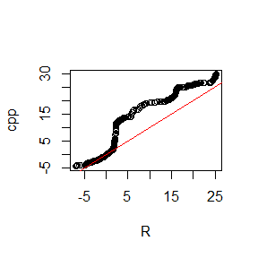

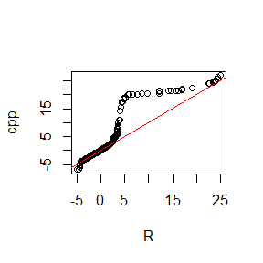

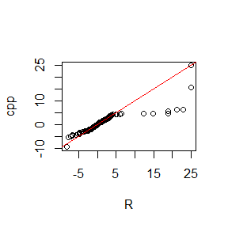

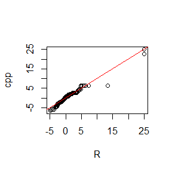

```r
rw1 <- cbind(rw11$x, rw21$x, rw31$x, rw41$x)
rw2 <- cbind(rw12[[1]], rw22[[1]], rw32[[1]], rw42[[1]])
for(i in 1:4){
qqplot(rw1[,i],rw2[,i],xlab="R",ylab="cpp")
abline(0,1,col="red")
}
```

## Question3

Campare the computation time of the two functions with microbenchmark.

## Answer3

```r
library(microbenchmark)
ts <- microbenchmark(rw11 <- rw.Metropolis( sigma[1], x0, N),
rw21 <- rw.Metropolis( sigma[2], x0, N),
rw31 <- rw.Metropolis( sigma[3], x0, N),
rw41 <- rw.Metropolis( sigma[4], x0, N),
rw12 <- rwM( sigma[1], x0, N),
rw22 <- rwM( sigma[2], x0, N),
rw32 <- rwM( sigma[3], x0, N),
rw42 <- rwM( sigma[4], x0, N))
summary(ts)[,c(1,3,5,6)]
```

```
##                                     expr      lq  median      uq
## 1 rw11 <- rw.Metropolis(sigma[1], x0, N) 5021.50 5097.40 5186.15
## 2 rw21 <- rw.Metropolis(sigma[2], x0, N) 5022.15 5098.30 5181.20
## 3 rw31 <- rw.Metropolis(sigma[3], x0, N) 5078.35 5156.65 5261.55
## 4 rw41 <- rw.Metropolis(sigma[4], x0, N) 5093.60 5152.30 5257.80
## 5           rw12 <- rwM(sigma[1], x0, N)  231.90  236.05  245.60
## 6           rw22 <- rwM(sigma[2], x0, N)  274.30  277.70  289.15
## 7           rw32 <- rwM(sigma[3], x0, N)  280.50  283.70  297.10
## 8           rw42 <- rwM(sigma[4], x0, N)  278.10  281.90  288.20
```

## Question4

Comments your results.

## Answer4

In the qqplot,The data don’t match very well between R and Rcpp.But the difference is not far.

The computation time of Rcpp is less than R.Rcpp is so fast.